# MCMCtreeR: plotting time trees

Mark Puttick

marknputtick@gmail.com

University of Bath

21 May 2019

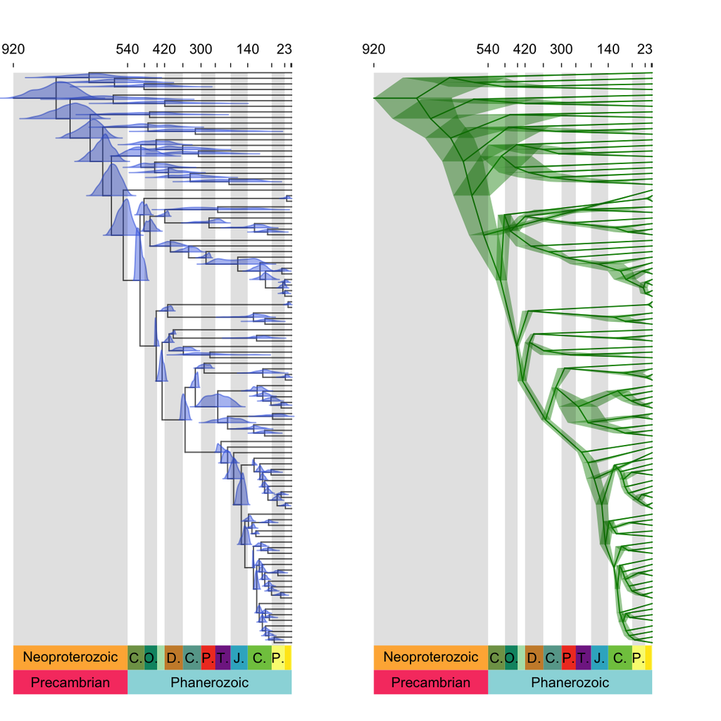

This guide demonstrates the `MCMC.tree.plot` function that plots time trees output from divergence time analysis using the molecular (or morphological) clock. `MCMC.tree.plot` includes options to plot the Bayesian HPD age distribution for each node as node bars or the full distribution, and also includes arguments to plot a geological and/or absolute timescale.

`MCMC.tree.plot` can take any timescaled tree from any software as long as it is read into R in [APE](https://CRAN.R-project.org/package=ape) format. The function contains methods to read in and summarise posterior age estimates for analyses from [MrBayes](http://nbisweden.github.io/MrBayes/), [RevBayes](https://revbayes.github.io/), and [MCMCtree](http://abacus.gene.ucl.ac.uk/software/paml.html). However **any** tree and uncertainty can be plotted the phylogeny and posterior age estimates are given as arguments to the function.

# Installation

The data in these examples are taken from an MCMCtree divergence time analysis. [Morris *et al* 2018](https://doi.org/10.1073/pnas.1719588115). From the `MCMCtreeR` package, users can directly call (using the `data` function) the object `MCMCtree.output` that contains a phylogeny output from MCMCtree `MCMCtree.phy` and a full posterior output from the analysis `MCMCtree.posterior`.

```r
if (!any(rownames(installed.packages()) == "MCMCtreeR")) install.packages("MCMCtreeR")
library(MCMCtreeR, quietly = TRUE, warn.conflicts = FALSE)
data(MCMCtree.output)
attach(MCMCtree.output)
names(MCMCtree.output)
```

```
## [1] "MCMCtree.phy"       "MCMCtree.posterior"
```

```r
phy <- readMCMCtree(MCMCtree.phy, from.file = FALSE)
```

# Plot geological and absolute ages on plot

For all plot types, `MCMC.tree.plot` includes options to incorporate absolute and geological timescales on the tree figure. For example, in Figure 1 the geologic times Eon and Period are displayed at the bottom of the tree, with absolute ages in millions of years before present at the top. The plotting of absolute timescales is controlled by setting the `add.time.scale` option to `TRUE` (the default). The absolute ages that are included reflect the designations marked by the geologic time periods `scale res` argument. So here absolute ages are shown for each Period at the top of the plot. As `grey.bars` is `TRUE` shading is also used to delimit each geologic Period.

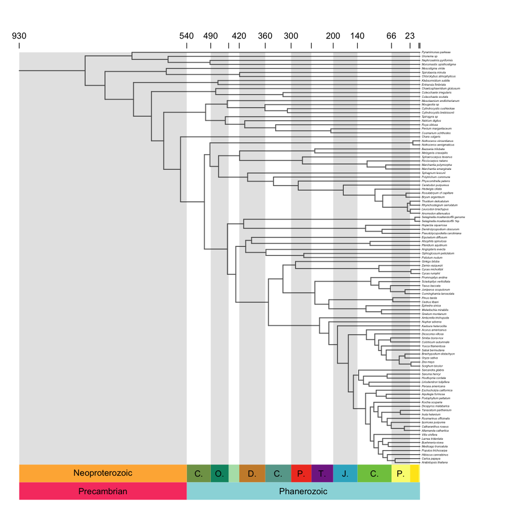

```r
MCMC.tree.plot(phy, cex.tips = 0.2, time.correction = 100, scale.res = c("Eon",
    "Period"), plot.type = "phylogram", cex.age = 0.6, cex.labels = 0.6,
    relative.height = 0.08, col.tree = "grey40", label.offset = 4,
    node.method = "none", no.margin = TRUE)
```

In Figure 2, the same plot is shown with `scale res` set to show all geological age options (Eon, Period, Epoch, Age), which looks too busy for this tree as it spans > 900 million years, but may be better for other trees that span smaller time frames.

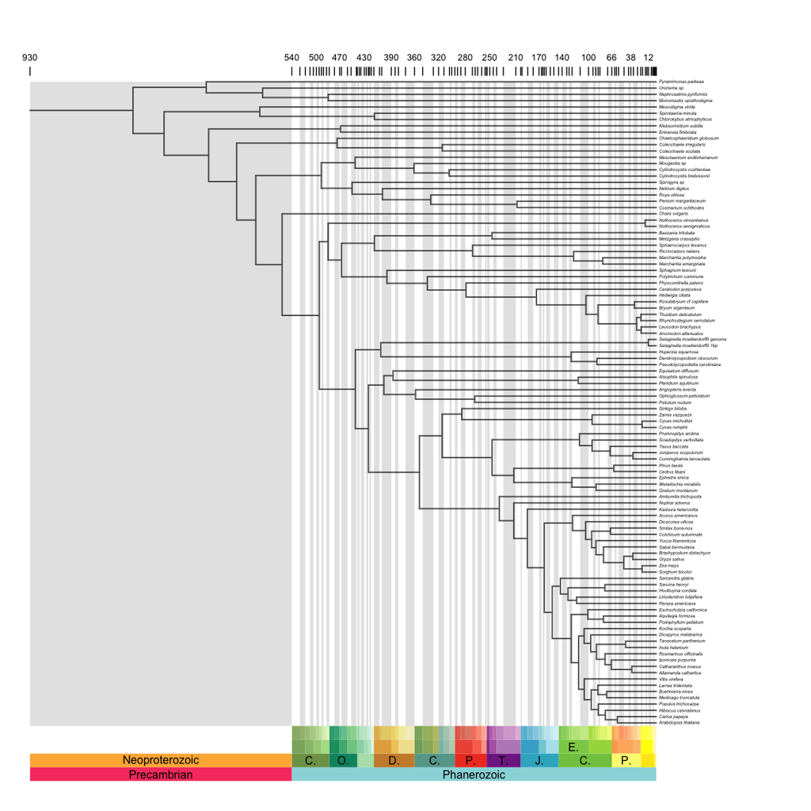

```r
MCMC.tree.plot(phy, cex.tips = 0.2, time.correction = 100, scale.res = c("Eon",
    "Period", "Epoch", "Age"), plot.type = "phylogram", cex.age = 0.4,
    cex.labels = 0.5, relative.height = 0.08, col.tree = "grey40",
    label.offset = 4, node.method = "none", no.margin = TRUE)
```

# Plot node uncertainty

Timescaled phylogenies can be plotted as the default ‘phylogram’ type. On these phylogenies uncertainty can be plotted as node bars, similar to those used in [FigTree](http://beast.community/figtree). Note the argument `time.correction` is used to rescale the MCMCtree ages to absolute time by multiplying all ages by 100. In Figure 3, uncertainty is presented using bars to highight the upper and lower Highest Posterior Density of each age.

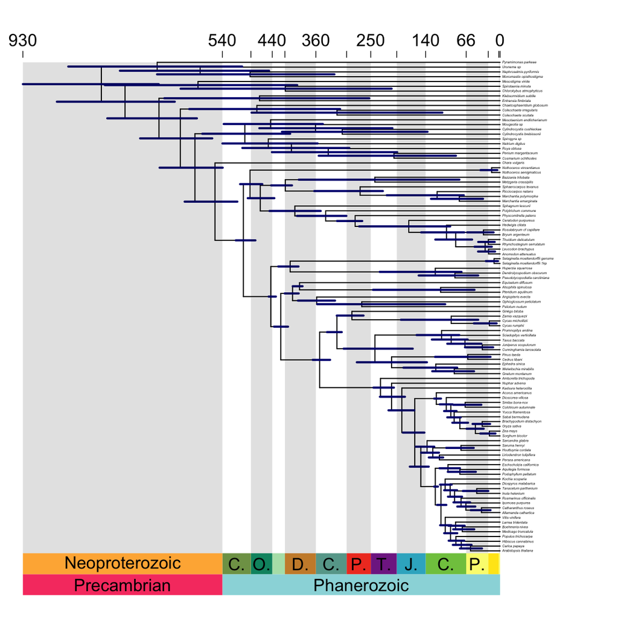

**Figure 3** Phylogeny with age uncertainty displayed as bars on nodes.

```r
MCMC.tree.plot(phy, analysis.type = "MCMCtree", cex.tips = 0.2,
    time.correction = 100, plot.type = "phylogram", lwd.bar = 2,
    scale.res = c("Eon", "Period"), node.method = "bar", col.age = "navy",
    no.margin = TRUE, label.offset = 4)
```

In this example (Figure 4), the age range of uncertainty for bars are spread across the vertical height of each node using the option `node.length`.

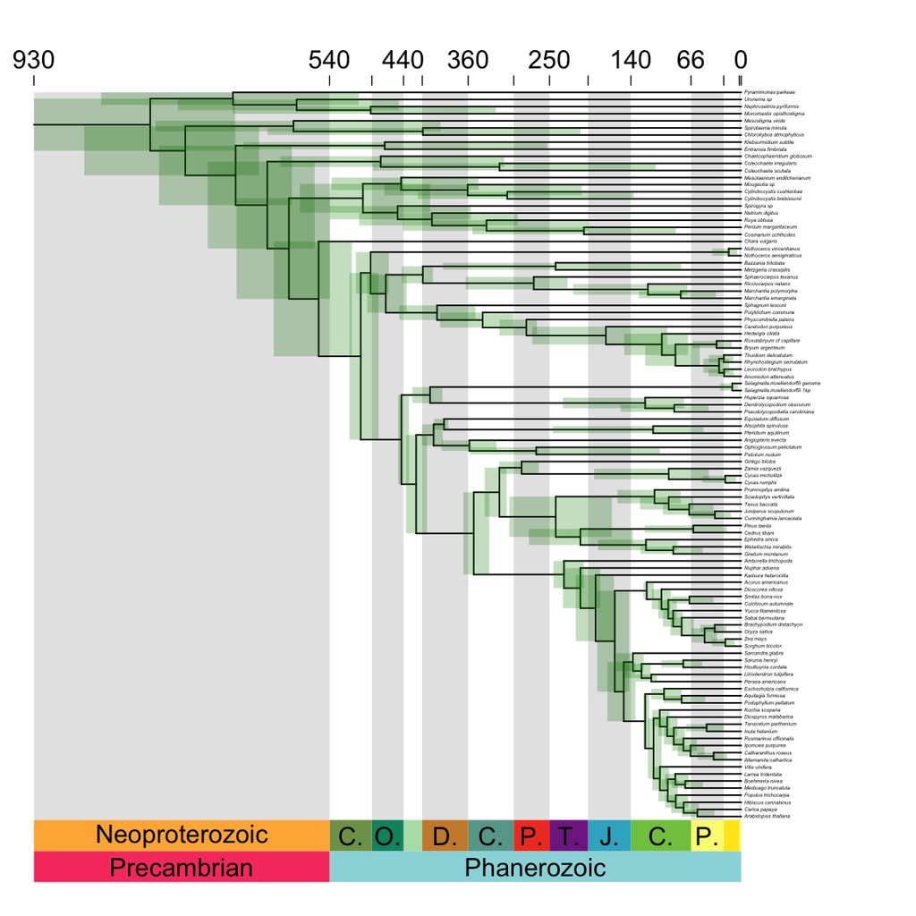

**Figure 4** Phylogeny with age uncertainty displayed spanning the vertical height of the node.

```r
MCMC.tree.plot(phy, analysis.type = "MCMCtree", cex.tips = 0.2,
    time.correction = 100, plot.type = "phylogram", lwd.bar = 2,
    scale.res = c("Eon", "Period"), node.method = "node.length",
    col.age = "#008b0040", no.margin = TRUE, label.offset = 4)
```

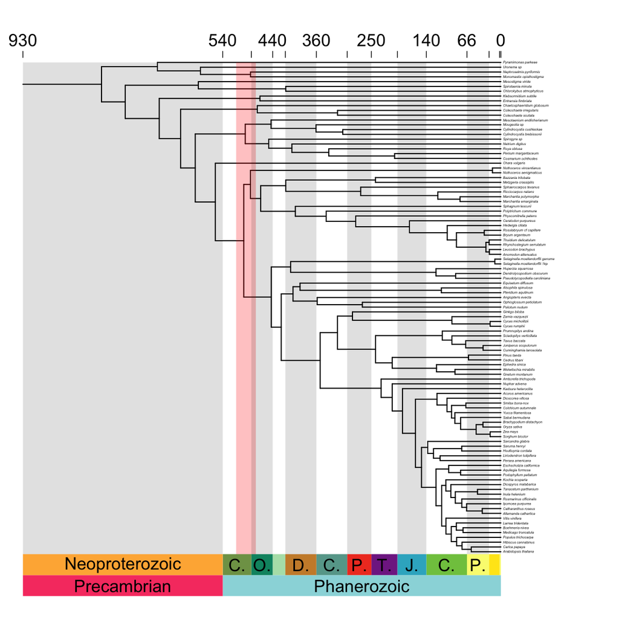

**Figure 5** Phylogeny with age uncertainty of one node spanning the height of the phylogeny.

```r
MCMC.tree.plot(phy, analysis.type = "MCMCtree", cex.tips = 0.2,
    time.correction = 100, plot.type = "phylogram", lwd.bar = 2,
    scale.res = c("Eon", "Period"), node.method = "full.length",
    all.nodes = 110, col.age = "#ff000040", no.margin = TRUE,
    label.offset = 4)
```

## Mrbayes

The above examples were for MCMCtree analyses, these plots can also be produced for MrBayes trees. Here no tree object is provided but the full directory to the tree file is provided for the `directory.files` argument. This is then read in and plotted by the function.

```r
# directory.mb <- '/User/MrBayes/output.nex.con.tre'
# MCMC.tree.plot(analysis.type='mrbayes',
# directory.files=directory.mb, cex.tips=0.33,
# plot.type='phylogram', lwd.bar=2, add.time.scale=FALSE,
# node.method='bar', col.age='navy')
```

## RevBayes

RevBayes trees can read in the same way as MrBayes trees.

```r
# directory.rb <- '/User/RevBayes/output.nex.con.tre'
# MCMC.tree.plot(analysis.type='revbayes',
# directory.files=directory.rb, cex.tips=0.33,
# plot.type='phylogram', lwd.bar=2, add.time.scale=FALSE,
# node.method='bar', col.age='navy')
```

## Cladogram

Cladogram trees can be plot for output from MCMCtree analysis. In Figure 6, the ‘MCMCtree’ node uncertainty is summarised using phylogenetic cladogram plot in which with HPD age uncertainty spans the entire branch length.

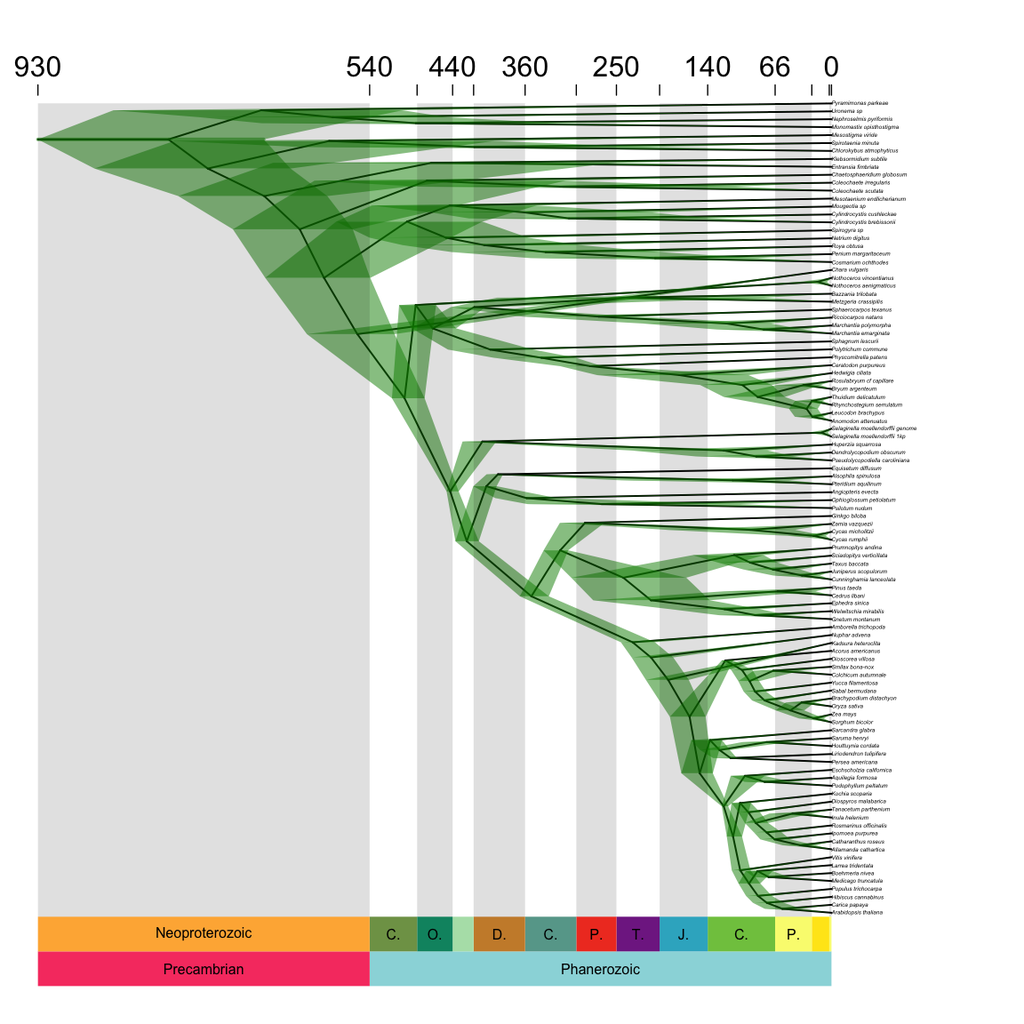

**Figure 6** Cladogram plot

```r
MCMC.tree.plot(phy, analysis.type = "MCMCtree", cex.tips = 0.2,
    time.correction = 100, plot.type = "cladogram", lwd.bar = 2,
    scale.res = c("Eon", "Period"), node.method = "node.length",
    col.age = "#008b0080", no.margin = TRUE, cex.labels = 0.5)
```

# Plot full distribution on nodes

If the full posterior is supplied as well as the tree, the `plot.type` argument can be set to `distributions` to display the full distribution of age estimates for each node of the plot. In Figure 7, the full sample of ages is displayed for every node on the phylogeny.

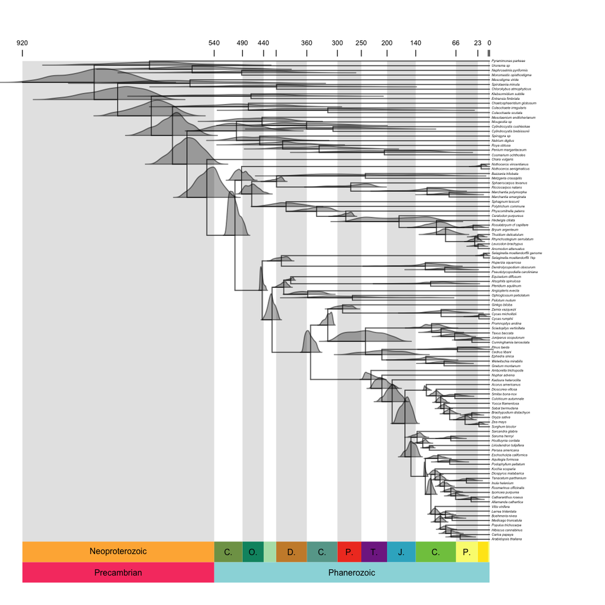

**Figure 7** Phylogeny with posterior distributions of age on nodes.

```r
MCMC.tree.plot(phy, MCMC.chain = MCMCtree.posterior, cex.tips = 0.2,
    time.correction = 100, plot.type = "distributions", cex.age = 0.4,
    cex.labels = 0.5, relative.height = 0.08, col.tree = "grey40",
    scale.res = c("Eon", "Period"), no.margin = TRUE, label.offset = 4,
    density.col = "#00000050", density.border.col = "#00000080")
```

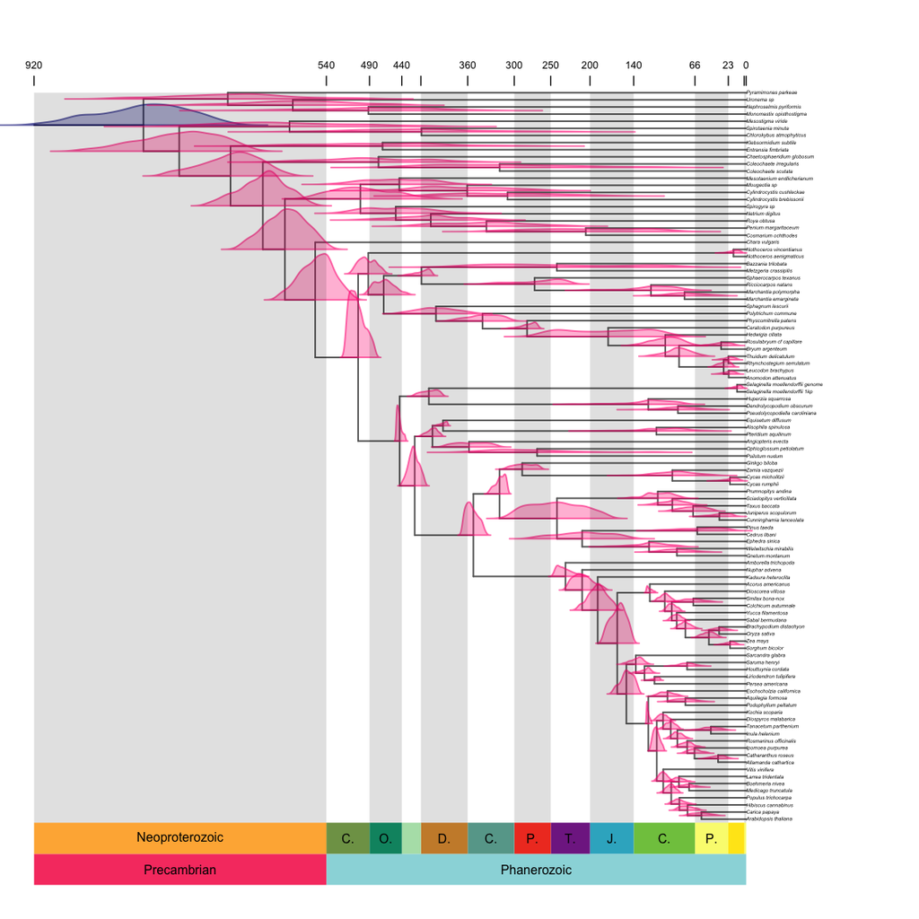

**Figure 8** Phylogeny with posterior distributions of age on nodes, with the root a different colour.

```r
node.colours <- rep("#ff008050", Nnode(phy$apePhy))
node.colours.border <- rep("#ff008090", Nnode(phy$apePhy))
node.colours[1] <- "#00008050"
node.colours.border[1] <- "#00008090"
MCMC.tree.plot(phy, MCMC.chain = MCMCtree.posterior, cex.tips = 0.2,
    time.correction = 100, scale.res = c("Eon", "Period"), plot.type = "distributions",
    cex.age = 0.4, cex.labels = 0.5, relative.height = 0.08,
    col.tree = "grey40", col.age = "black", density.col = node.colours,
    density.border.col = node.colours.border, grey.bars = TRUE,
    no.margin = TRUE)
```

# Plot tree and timescale from any software

Using the ‘user’ option in the argument `analysis.type` it is possible to plot trees, timescales, and age uncertainty, with files output from any software.

The function only needs to be provided with a time-scaled phylogeny, and the full posterior age estimates for each node. This user input information is provided as a list to the argument `node.ages`.

For this example, we are using the MCMCtree output, but the process should be applicable to any divergence time software output. The `MCMC.tree.plot` function requires that the object `node.ages` is organised so the each element contains the full age posterior for each node, and this element is allocated a name that match the labels APE tree$edge object. The first element in the list supplied to `node.ages` is the root node.

Here the ‘user’ approach is set-up step-by-step. First we store the tree in APE format as a new object, and also create a new object for the `phy$edge` object which summarises the tree structure in the APE matrix format. Finally the MCMC chain is stored as a new object. For the purposes of these examples, we use a subset of the phylogeny the descends from node 177.

```r
data(MCMCtree.output)
attach(MCMCtree.output)
```

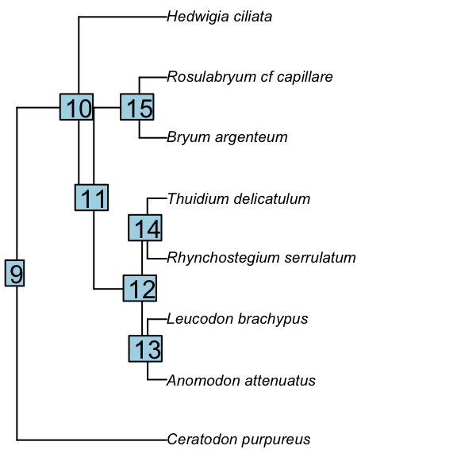

**Figure 9** Phylogeny showing the node and tip labels.

```r
phy <- readMCMCtree(MCMCtree.phy, from.file = FALSE)
phy <- phy$apePhy
# Here a smaller tree is shown as an example.
phy.small <- extract.clade(phy, 177)
plot(phy.small, no.margin = TRUE, cex = 0.6)
# view nodelabels on the tree
nodelabels(cex = 1)
```

This tree plot in Figure 9 shows the timescaled phylogeny. On this plot the blue squares correspond to internal node labels. The input needs a list with each element containing the ages from the appropriate node (Figure 9).

Here the list is constructing and each element name is assigned with the corresponding node value, and these are filled with random ages from a normal distribution. In a real example this would be subsituted with real data.

```r
node.numbers <- c(9, 10, 11, 12, 13, 14, 15)
# create a list to store each posterior sample for every node
node.posteriors <- vector(mode = "list", length = Nnode(phy.small))
names(node.posteriors) <- node.numbers
for (i in 1:Nnode(phy.small)) node.posteriors[[i]] <- rnorm(1000,
    mean = branching.times(phy.small)[i], sd = 0.1)
## substitute the random numbers with the appropriate
## posterior distribution for that node e.g., your.age.values
## <- read.csv('posterior.ages.from.an.analysis') for(i in
## 1:Nnode(phy.small)) node.posteriors[[i]] <- your.age.values
```

These data can now be displayed using the `MCMC.tree.plot` function (Figure 10) in which the node.posteriors are provided to the function as a list using the `node.ages argument`.

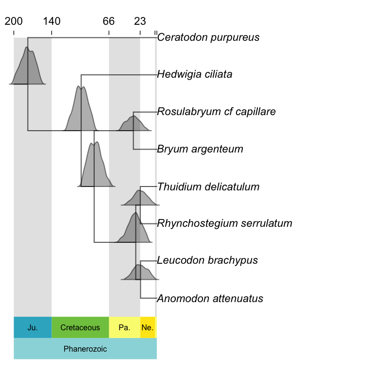

**Figure 10** Phylogeny showing the node and tip labels.

```r
MCMC.tree.plot(phy = phy.small, node.ages = node.posteriors,
    analysis.type = "user", cex.tips = 0.7, time.correction = 100,
    scale.res = c("Eon", "Period"), plot.type = "distributions",
    cex.age = 0.7, cex.labels = 0.5, relative.height = 0.08,
    col.tree = "grey40", no.margin = TRUE)
```

This is a second example in which we use real data from an MCMCtree analysus. Again, the names of the list elements storing the posterior age arguments need match the nodelabels from the APE tree. As above, a good way to investigate this is to plot trees and then using the `nodelabels()` function to visualise how the nodelabels are found on the tree.

In the MCMCtree output file, node ages are stored in the second column onwards. So we extract these data and then remove the ‘t_n’ label from each column header so we are left with just the node numbers. And then we sort the node numbers from MCMCtree analysis so that they match the node labels in the APE format.

```r
# Not run. Plot tree with node labels to help work out how
# labels correspond to tree from software output.  plot(ape)
# nodelabels() extract the MCMC chain and the phylogeny edge
# object
MCMC.chain <- MCMCtree.posterior
phy.edge <- phy$edge
# extract ages with node age posteriors from column 2
MCMC.node.ages <- MCMC.chain[, 2:Ntip(phy)]
# extract the names from these data so they are numeric node
# labels that match the APE tree format
all.nodes <- as.numeric(gsub("t_n", "", colnames(MCMC.node.ages)))
# create a vector of names for each list element as internal
# nodes from APE tree, using phy$edge object.
node.ages.names <- c(Ntip(phy) + 1, phy.edge[which(phy.edge[,
    2] > Ntip(phy)), 2])
# find where each posterior node age appears in APE edge
# object.
match.nodes <- match(all.nodes, as.numeric(node.ages.names))
# create a list extracting the information from the MCMC
# chain in APE node order.
node.ages <- lapply(match.nodes, function(uu) MCMC.node.ages[,
    uu])
# name each element in list.
names(node.ages) <- node.ages.names
```

The `node.ages` object is input to `MCMC.tree.plot` with the argument `analysis.type` set to ‘user’ to plot the timescaled tree and full distributions on each node (Figure 11).

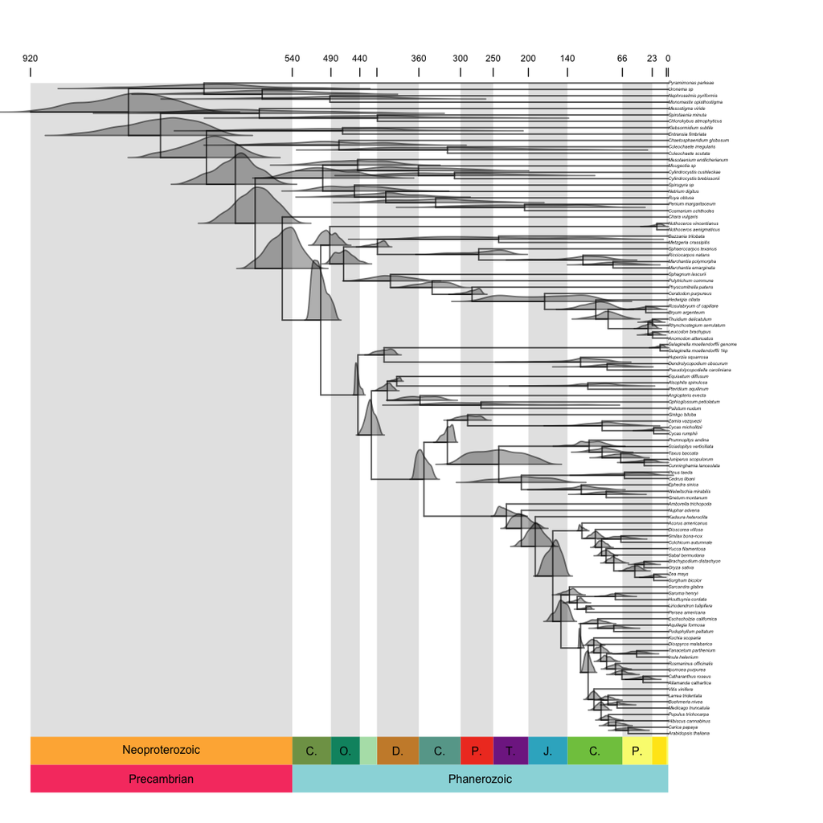

**Figure 11** Phylogeny plotted with user-formatted data.

```r
MCMC.tree.plot(phy = phy, node.ages = node.ages, analysis.type = "user",
    cex.tips = 0.2, time.correction = 100, scale.res = c("Eon",
        "Period"), plot.type = "distributions", cex.age = 0.4,
    cex.labels = 0.5, relative.height = 0.08, col.tree = "grey40",
    no.margin = TRUE)
```

**References**

- Morris JL, Puttick MN, Clark JW, Edwards, Kenrick PD, Pressel S, Wellman CH, Yang Z, Schneider H, and Donoghue PCJ. 2018. The timescale of early land plant evolution. **Proceedings of the National Academy of Sciences USA**. (https://doi.org/10.1073/pnas.1719588115)